# STAT 230

February 21, 2017

# Yet more on regression

Wow, I just knit this, and it looks like a *long* page! That’s mostly because there are a lot of plots and output, much of which is meant just for a quick look and smooth scrolling. And there’s a table of contents on the left that I hope will help further ease navigation.

## Body fat data

Last time we decided to remove two cases from the data set: rows 39 and 42

```r
library(MASS)
b <- read.csv("http://www.stat.yale.edu/~jtc5/STAT230/data/bodyfat-252.csv")
b <- b[-c(39,42), ]
n <- nrow(b)
```

```r
ma <- lm(bf ~ abdomen, data=b)
summary(ma)
```

```
##
## Call:
## lm(formula = bf ~ abdomen, data = b)
##
## Residuals:
##      Min       1Q   Median       3Q      Max
## -10.8987  -3.6453   0.1864   3.1775  12.7887
##
## Coefficients:
##              Estimate Std. Error t value Pr(>|t|)
## (Intercept) -42.73413    2.71651  -15.73   <2e-16 ***
## abdomen       0.66928    0.02926   22.88   <2e-16 ***
## ---
## Signif. codes:  0 '***' 0.001 '**' 0.01 '*' 0.05 '.' 0.1 ' ' 1
##
## Residual standard error: 4.713 on 248 degrees of freedom
## Multiple R-squared:  0.6785, Adjusted R-squared:  0.6772
## F-statistic: 523.3 on 1 and 248 DF,  p-value: < 2.2e-16
```

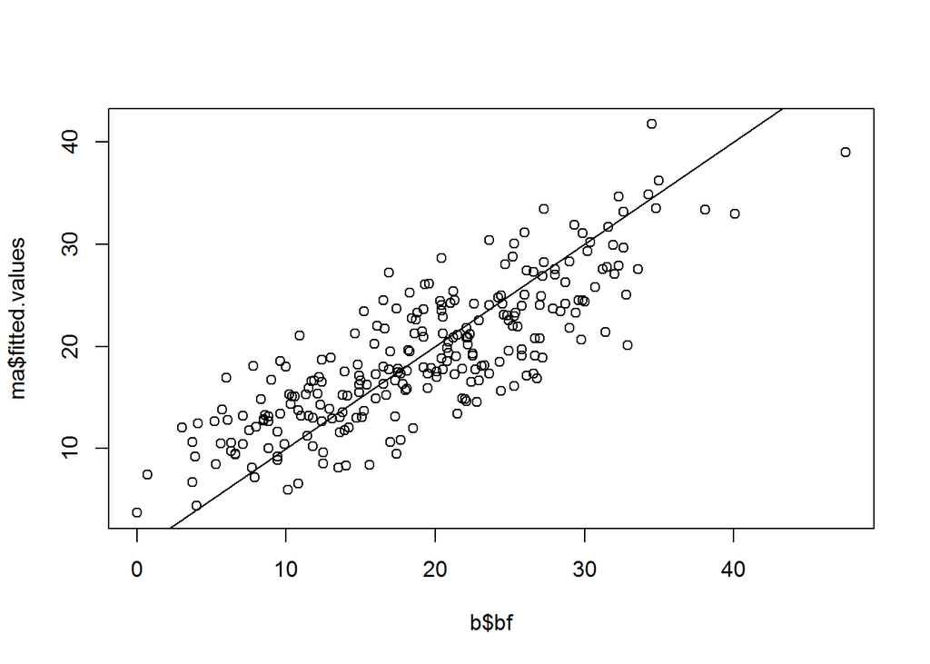

```r
# Look at R-squared (.6785)
# Residual standard error: 4.713
plot(ma$fitted.values ~ b$bf)
abline(0,1)
```

```r
mh <- lm(bf ~ height, data=b)
summary(mh)
```

```
##
## Call:
## lm(formula = bf ~ height, data = b)
##
## Residuals:
##      Min       1Q   Median       3Q      Max
## -19.2461  -6.6605   0.2566   6.1433  27.8812
##
## Coefficients:
##             Estimate Std. Error t value Pr(>|t|)
## (Intercept) 25.58078   14.15400   1.807   0.0719 .
## height      -0.09316    0.20119  -0.463   0.6438
## ---
## Signif. codes:  0 '***' 0.001 '**' 0.01 '*' 0.05 '.' 0.1 ' ' 1
##
## Residual standard error: 8.307 on 248 degrees of freedom
## Multiple R-squared:  0.0008637,  Adjusted R-squared:  -0.003165
## F-statistic: 0.2144 on 1 and 248 DF,  p-value: 0.6438
```

```r
# Look at R-squared (.00086)
# Residual standard error: 8.307
sd(b$bf)
```

```
## [1] 8.294
```

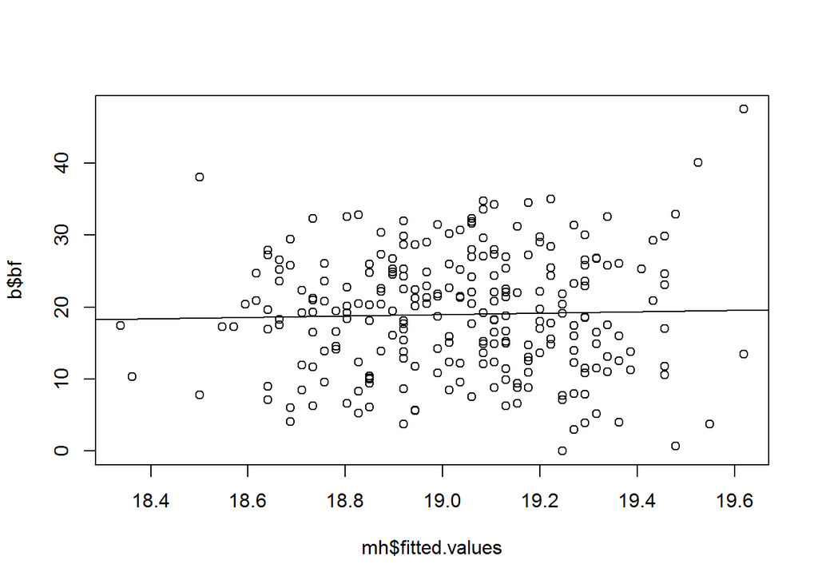

```r
# How close are our fitted values to the actual values?
plot(b$bf ~ mh$fitted.values)
abline(0,1)
```

```r
mha <- lm(bf ~ height + abdomen, data=b)
summary(mha)
```

```
##
## Call:
## lm(formula = bf ~ height + abdomen, data = b)
##
## Residuals:
##      Min       1Q   Median       3Q      Max
## -11.1692  -3.4133  -0.0977   3.0995   9.9082
##
## Coefficients:
##             Estimate Std. Error t value Pr(>|t|)
## (Intercept) -3.10088    7.68611  -0.403    0.687
## height      -0.60154    0.10994  -5.472 1.09e-07 ***
## abdomen      0.69807    0.02818  24.770  < 2e-16 ***
## ---
## Signif. codes:  0 '***' 0.001 '**' 0.01 '*' 0.05 '.' 0.1 ' ' 1
##
## Residual standard error: 4.46 on 247 degrees of freedom
## Multiple R-squared:  0.7132, Adjusted R-squared:  0.7109
## F-statistic: 307.1 on 2 and 247 DF,  p-value: < 2.2e-16
```

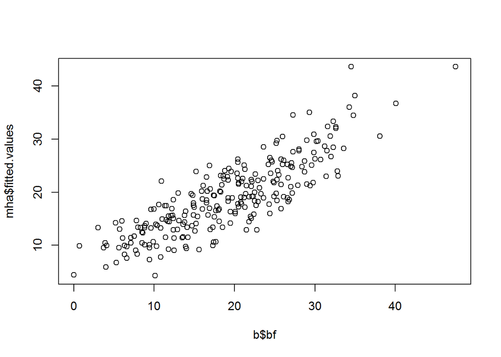

```r
# Look at R-squared (.7132)
# Residual standard error: 4.46
plot(mha$fitted.values ~ b$bf)
```

A big model including all columns:

```r
mall <- lm(bf ~ ., data=b)
mall
```

```
##
## Call:
## lm(formula = bf ~ ., data = b)
##
## Coefficients:
## (Intercept)          age       weight       height         neck
##     1.68516      0.07189     -0.01762     -0.24675     -0.38682
##       chest      abdomen          hip        thigh         knee
##    -0.11919      0.90452     -0.15878      0.17299     -0.04580
##       ankle       biceps      forearm        wrist
##     0.18502      0.17968      0.27605     -1.80162
```

```r
summary(mall)
```

```
##
## Call:
## lm(formula = bf ~ ., data = b)
##
## Residuals:
##      Min       1Q   Median       3Q      Max
## -10.9900  -3.1244  -0.1674   3.0248   9.8648
##
## Coefficients:
##             Estimate Std. Error t value Pr(>|t|)
## (Intercept)  1.68516   23.37412   0.072 0.942587
## age          0.07189    0.03217   2.234 0.026389 *
## weight      -0.01762    0.06714  -0.263 0.793153
## height      -0.24675    0.19114  -1.291 0.197989
## neck        -0.38682    0.23486  -1.647 0.100887
## chest       -0.11919    0.10825  -1.101 0.272004
## abdomen      0.90452    0.09140   9.897  < 2e-16 ***
## hip         -0.15878    0.14586  -1.089 0.277446
## thigh        0.17299    0.14683   1.178 0.239926
## knee        -0.04580    0.24560  -0.186 0.852230
## ankle        0.18502    0.21985   0.842 0.400862
## biceps       0.17968    0.17039   1.054 0.292732
## forearm      0.27605    0.20692   1.334 0.183454
## wrist       -1.80162    0.53304  -3.380 0.000848 ***
## ---
## Signif. codes:  0 '***' 0.001 '**' 0.01 '*' 0.05 '.' 0.1 ' ' 1
##
## Residual standard error: 4.255 on 236 degrees of freedom
## Multiple R-squared:  0.7505, Adjusted R-squared:  0.7368
## F-statistic: 54.61 on 13 and 236 DF,  p-value: < 2.2e-16
```

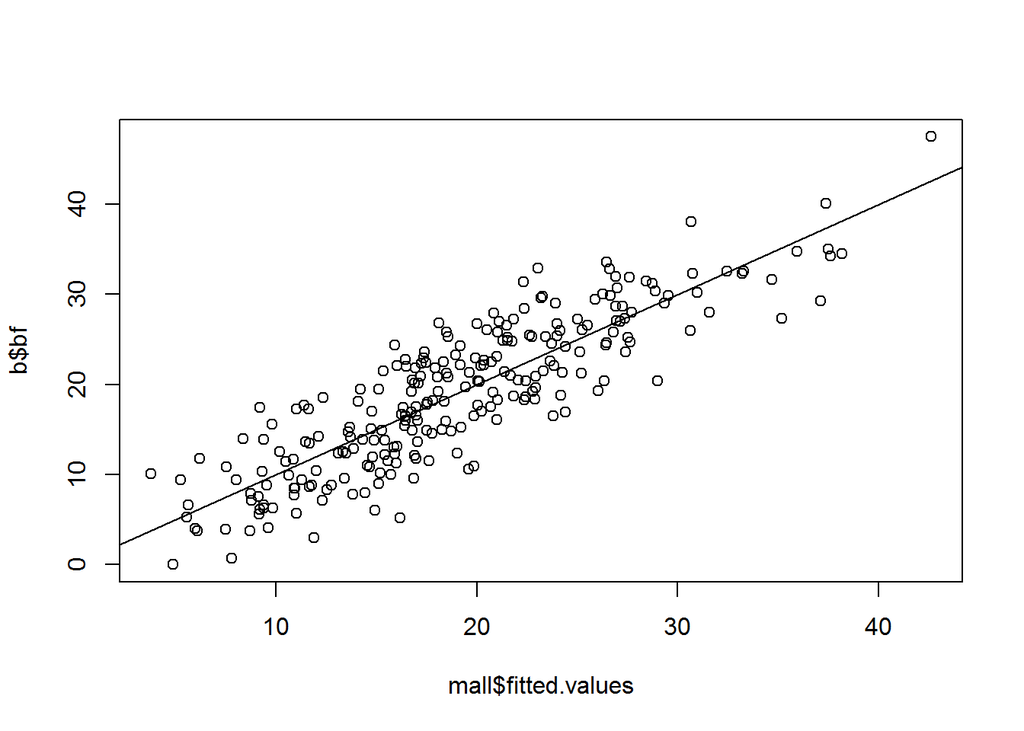

```r
# R-squared is .7505
# Residual standard error: 4.255
plot(b$bf ~ mall$fitted.values)
abline(0,1)
```

NOTES

- Thing can change back and forth… e.g. now height is no longer significant.
- But R-squared is higher.
- The plot we’ve been doing will tend to overstate how good our predictions are expected to be. See below.

```r
summaries <- list(mh=summary(mh), ma=summary(ma), mha=summary(mha), mall=summary(mall))
sapply(summaries, function(x){x$r.squared})
```

```
##          mh          ma         mha        mall
## 0.000863748 0.678456403 0.713216630 0.750494710
```

```r
sapply(summaries, function(x){x$adj.r.squared})
```

```
##           mh           ma          mha         mall
## -0.003165027  0.677159856  0.710894497  0.736750774
```

```r
sapply(summaries, function(x){x$sigma})
```

```
##       mh       ma      mha     mall
## 8.307115 4.712570 4.459562 4.255471
```

## Model selection

Note the big model `mall` has the highest R-squared. Why not just use it?

### Example: Polynomials

This is to help get more insight into the problem of model selection.

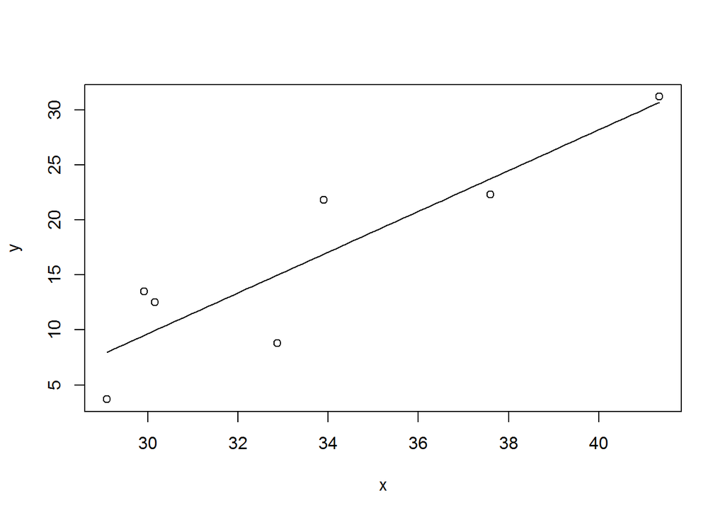

```r
# Sample 7 rows at random from the data:
set.seed(230)
rows <- sample(nrow(b),7)

bs <- b[rows,]

y <- bs$bf
x <- bs$abdomen/2.54
ord <- order(x)
x <- x[ord]
y <- y[ord]
plot(y~x)

L <- min(x); U <- max(x)
newdat <- data.frame(x = seq(L, U, length.out = 100))

#Least squares linear fit:
lm1 = lm(y~x)
pred <- predict(lm1, newdata = newdat)
lines(newdat$x, pred)
```

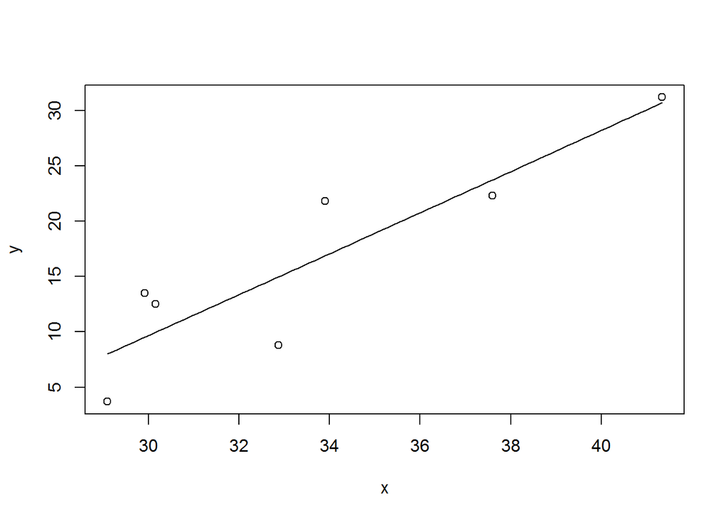

```r
# Quadratic:
lm2 <- lm(y~x + I(x^2))
pred <- predict(lm2, newdata = newdat)
plot(y~x)
lines(newdat$x, pred)
```

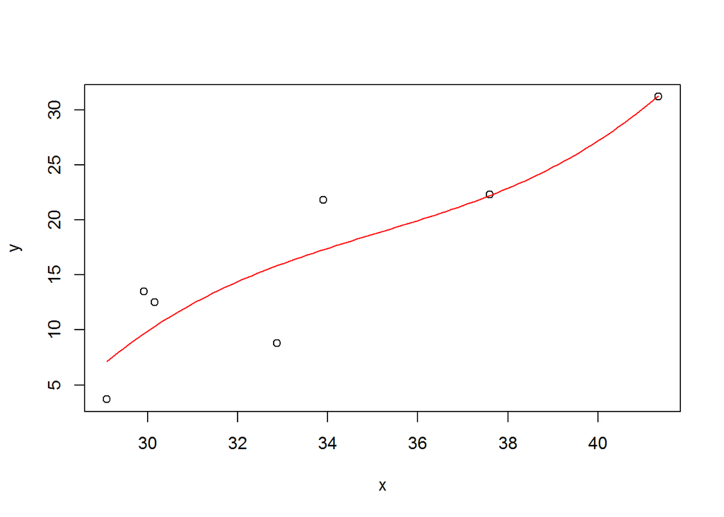

```r
# this is just kind of a freakish coincidence that the coefficient
# of the squared term is so close to zero that this has negligible curvature.

# Higher degree polynomials:
lm3 <- lm(y~x + I(x^2) + I(x^3))
pred <- predict(lm3, newdata = newdat)
plot(y~x)
lines(newdat$x, pred)
# R tip: we can also use poly(x,d) to express polynomials of degree d.
lm3a <- lm(y ~ poly(x,3))
preda <- predict(lm3a, newdata = newdat)
lines(newdat$x, preda, col=2)
```

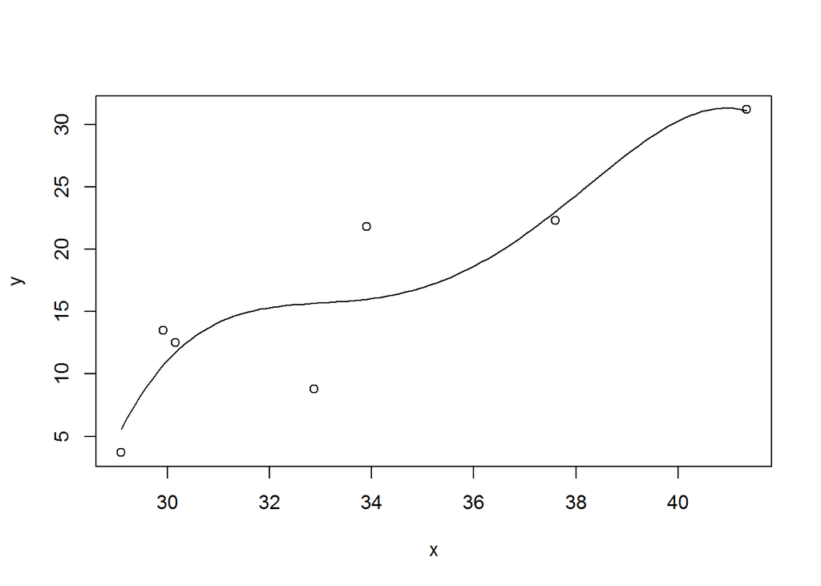

```r
lm4 <- lm(y~x + I(x^2) + I(x^3) + I(x^4))
pred <- predict(lm4, newdata = newdat)
plot(y~x)
lines(newdat$x, pred)
```

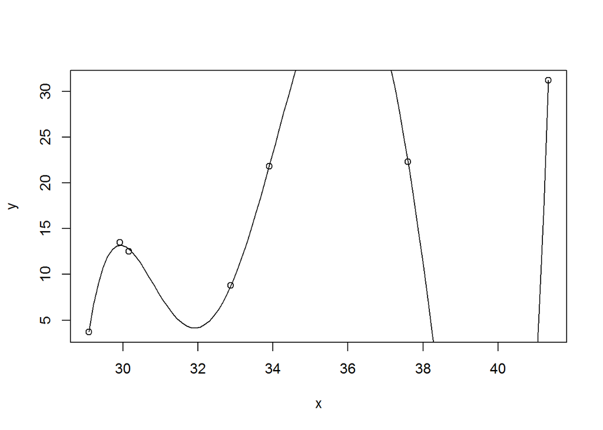

```r
lm5 <- lm(y~x + I(x^2) + I(x^3) + I(x^4) + I(x^5))
pred <- predict(lm5, newdata = newdat)
plot(y~x)
lines(newdat$x, pred)
```

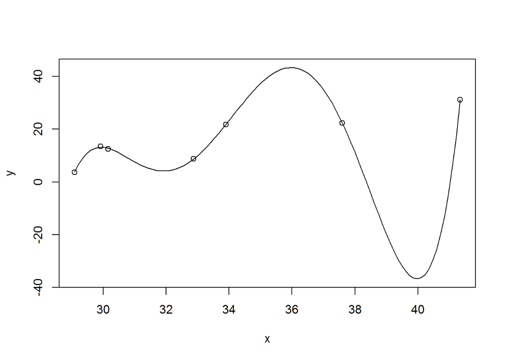

```r
yrange <- range(pred)
plot(y ~ x, ylim=yrange)
lines(newdat$x, pred)
```

Clearly if your waist is 38 inches and you want to get down to negative bf percentage, gain 2 more inches on your waist!

```r
lm6 <- lm(y~x + I(x^2) + I(x^3) + I(x^4) + I(x^5) + I(x^6))
pred <- predict(lm6, newdata = newdat)
```

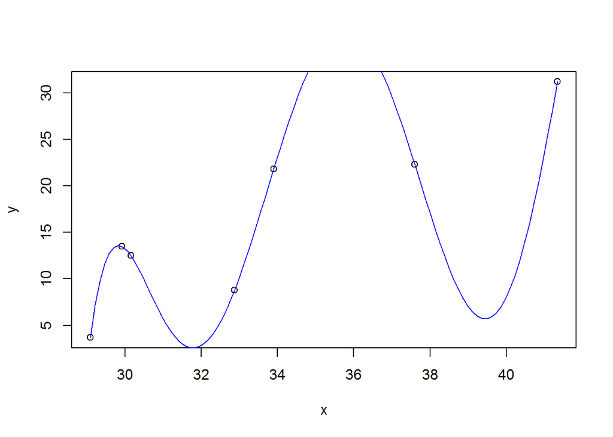

```r
# If you really want a 6th degree fit you can do it this way:
lm6 <- lm(y ~ poly(x,6))
pr <- predict(lm6, newdata = newdat)
plot(y ~ x)
lines(newdat$x, pr, col="blue")
```

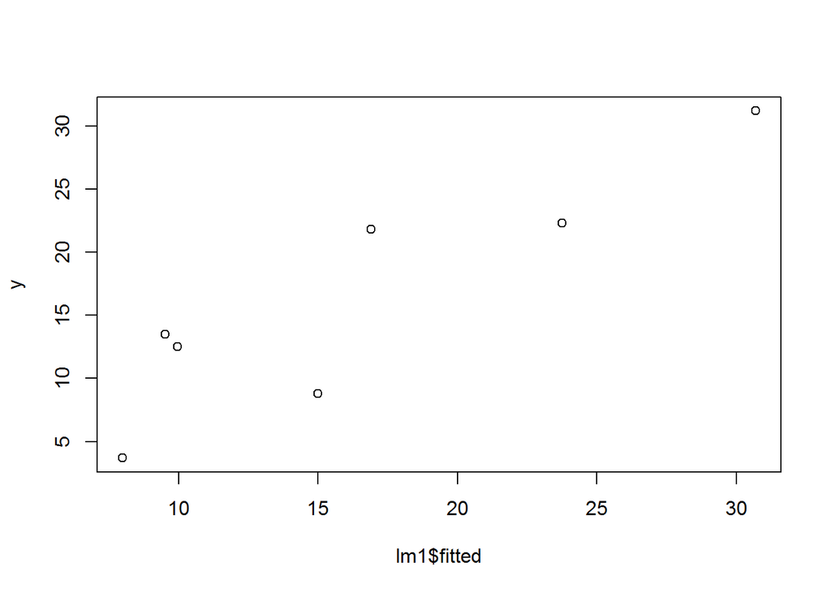

```r
# Overstating how good our predictions are:
plot(y ~ lm1$fitted)
```

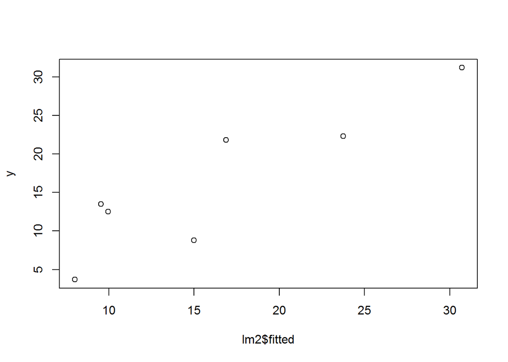

```r
plot(y ~ lm2$fitted)
```

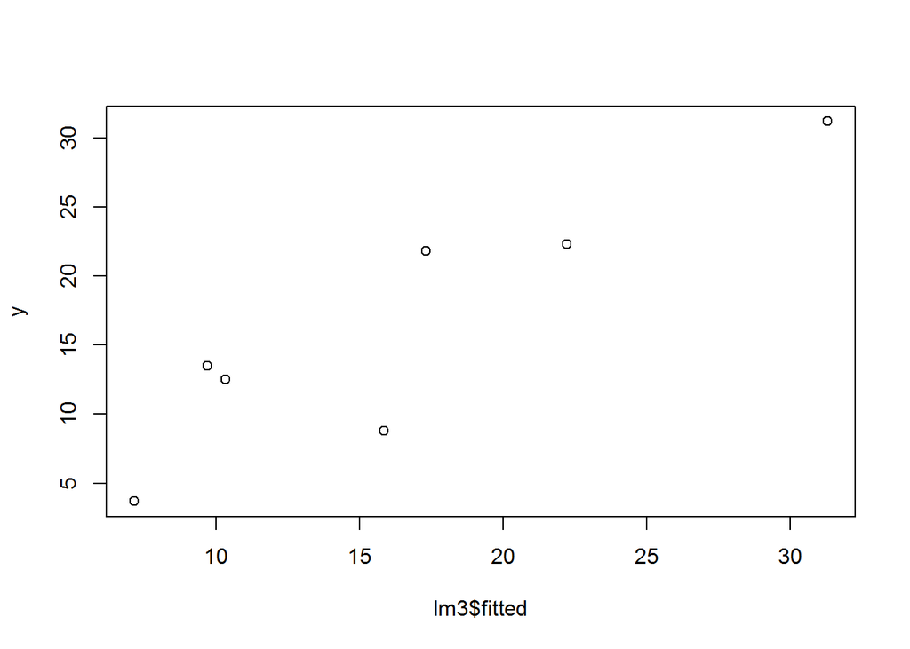

```r
plot(y ~ lm3$fitted)
```

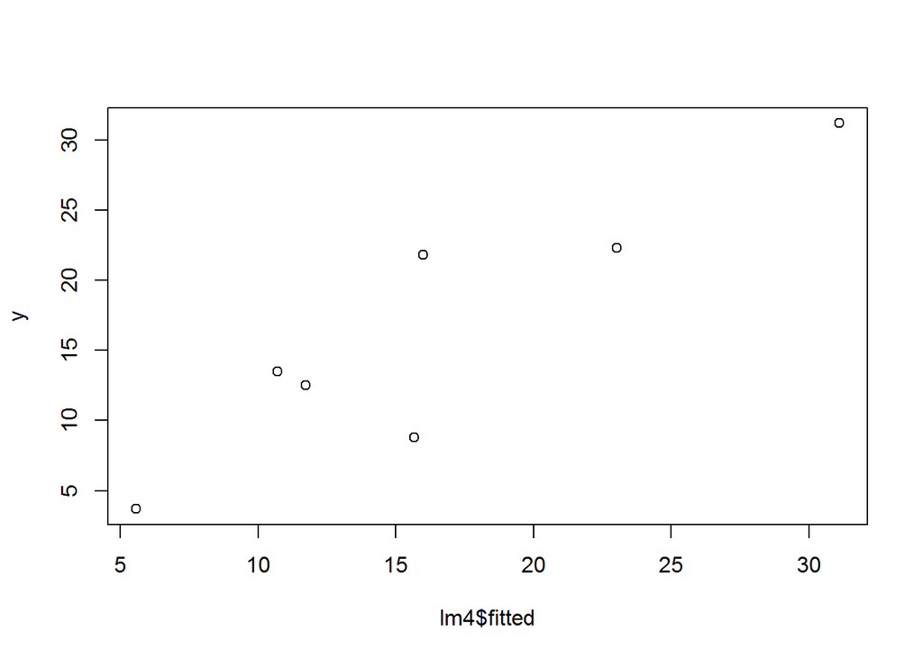

```r
plot(y ~ lm4$fitted)
```

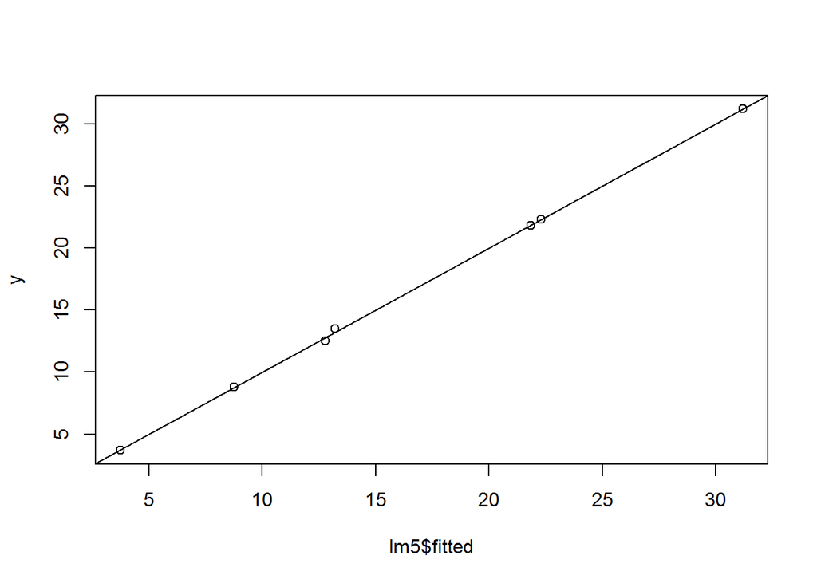

```r
plot(y ~ lm5$fitted); abline(0,1)
```

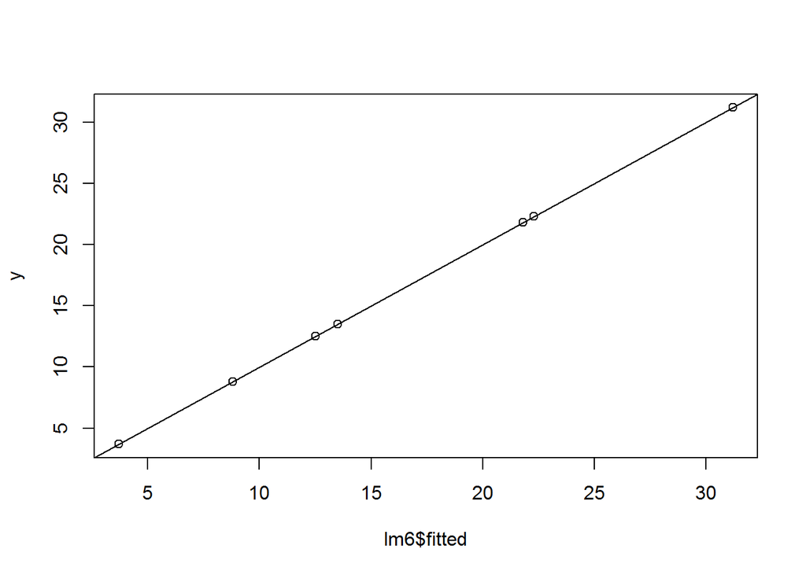

```r
plot(y ~ lm6$fitted); abline(0,1)
```

The plots for lm5 and lm6 look great, but we know these are bad models!

### Model selection criteria

The most famous one is “AIC”, which stands for “An Information Criterion,” due to Akaike.

Model selection is a deep problem and a lot of differing proposals have followed AIC, including BIC, BPIC, CIC, DIC, EIC, FIC, NIC, TIC, WAIC, … (don’t worry, I don’t know what all of these are either!) But AIC was the first to be proposed and still the most well known, and I believe it is still the most commonly used.

These model selection criteria generally start with some measure of how well the model fits the data at hand, and then penalize that fit by some measure of complexity of the model.

```r
extractAIC(lm3)
```

```
## [1]  4.00000 26.68653
```

```r
# Here, I'll write a function that shows what extractAIC is doing, for linear models
myaic <- function(lm1){
  res <- resid(lm1)
  n <- length(res)
  p <- lm1$rank
  return(n*log(mean(res^2)) + 2*p)
}
myaic(lm3) # see, it's the same as extractAIC(lm3)
```

```
## [1] 26.68653
```

So as we can see, AIC is measuring fit of the model to the data by the average squared residual (mean(res^2)). It takes log and multiplies by n. Still, so far, the smaller the better (smaller mean squared residual is better). The “penalty” is to add 2*p, that is, twice the number of parameters in the model (we can think of this as the number of coefficients in our linear model, including the intercept).

The next bit is included just for completeness, and you can probably skip it at least at first reading. I just wanted to point out that different authors and software may use definitions for AIC that look different and give different numbers, but in fact are “equivalent” to this one in the sense that if we are comparing models for some data set, the different versions of AIC will still rank the models in the same order of preference. Even within R there are two functions `extractAIC` and `AIC` that give different answers:

```r
extractAIC(mha)
```

```
## [1]   3.0000 750.5072
```

```r
myaic(mha)
```

```
## [1] 750.5072
```

```r
AIC(mha)  # ! differet from extractAIC (and myaic) !
```

```
## [1] 1461.976
```

```r
p <- 3 # for mha
myaic(mha) + n*log(2*pi) + n + 2 # so this is what AIC is doing
```

```
## [1] 1461.976
```

```r
# The extra addition of n*log(2*pi) + n + 2 doesn't affect
# comparison between models.
```

Formula used by extractAIC:
$$n\log(ASR) + 2p.$$

Formula used by AIC:
$$n\log(ASR) + 2(p+1) + n\log(2\pi) + n.$$

```r
extractAIC(lm1)
```

```
## [1]  2.00000 22.99056
```

```r
extractAIC(lm2)
```

```
## [1]  3.00000 24.99047
```

```r
extractAIC(lm3)
```

```
## [1]  4.00000 26.68653
```

```r
extractAIC(lm4)
```

```
## [1]  5.00000 28.12202
```

```r
extractAIC(lm5)
```

```
## [1]   6.00000 -13.69928
```

```r
extractAIC(lm6)
```

```
## [1]    7 -Inf
```

To get more of a feeling for “overfitting”… a start on the idea of cross-validation:

Do the next thing for d=1 and then d=3, for various i values (crl+shift+enter to run block)

```r
d <- 1
i <- 3
plot(y ~ x)
lm0 <- lm(y ~ poly(x,d))
newx <- seq(L,U,length.out = 100)
pr0 <- predict(lm0, data.frame(x=newx))
lines(newx, pr0)
yi <- y[-i]
xi <- x[-i]
lmi <- lm(yi ~ poly(xi,d))
ypredi <- predict(lmi, newdata = data.frame(xi=x[i]))
#^^ predicted y for ith point from regression not using ith point
ypredi
```

```
##        1
## 9.167004
```

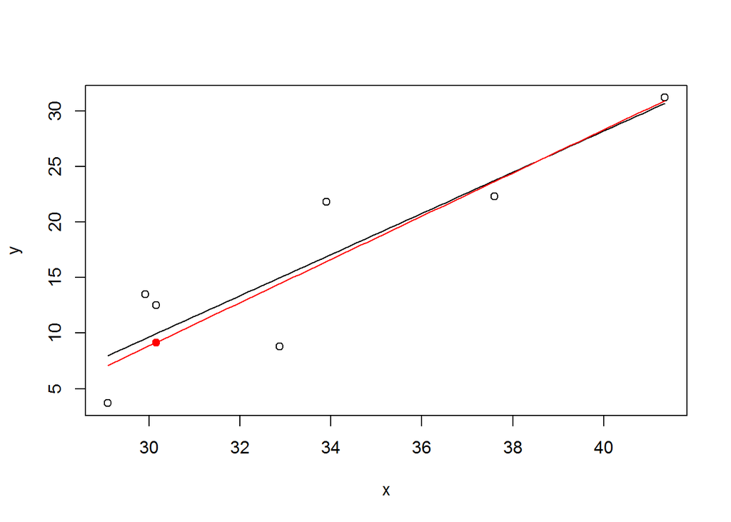

```r
points(x[i], ypredi, pch=19, col=2)
pri <- predict(lmi, data.frame(xi=newx))
lines(newx, pri, col=2)
```

```r
#^^ regression line not using ith point
```

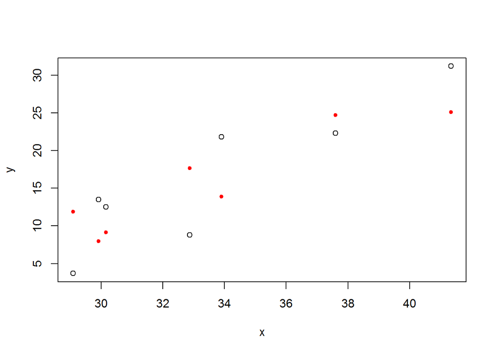

```r
d <- 2
ypred <- rep(NA, 7)
for(i in 1:7){
  yi <- y[-i]
  xi <- x[-i]
  lmi <- lm(yi ~ poly(xi,d))
  ypredi <- predict(lmi, newdata = data.frame(xi=x[i]))
  ypred[i] <- ypredi
}

myrange <- range(c(y, ypred))
plot(y ~ x, ylim=myrange)
points(x, ypred, col=2, pch=20)
```

```r
mean((y - ypred)^2)
```

```
## [1] 41.8595
```

To try to get a nice visual feeling for this, here I’ll write a function LOO (for “Leave One Out”) that shows the effect of leaving one point out of the data out.  
`LOO(d,i)` will do degree `d` polynomials, and show the fit to the full data set in black, and the fit to the data set with the ith point left out in red.

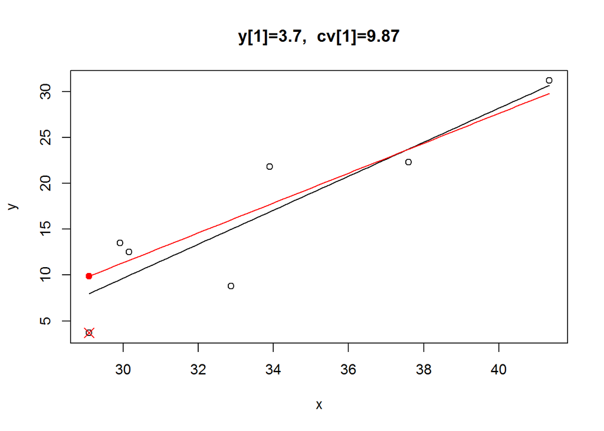

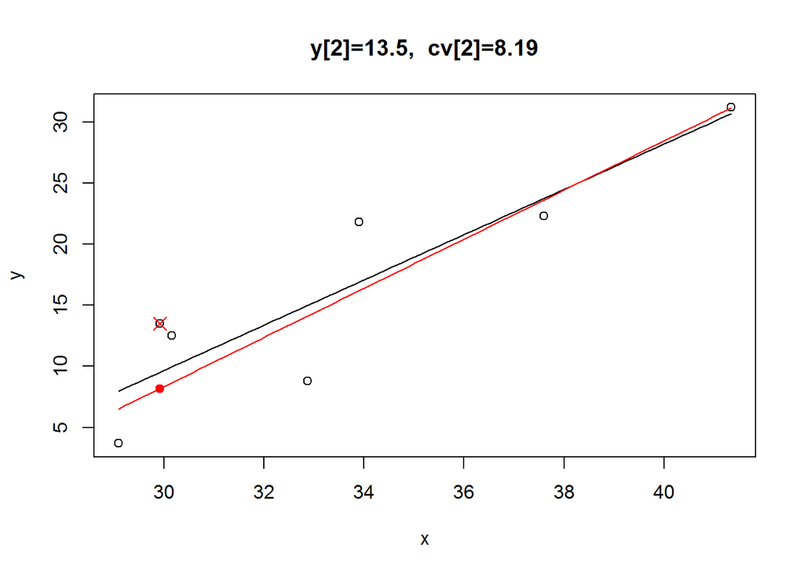

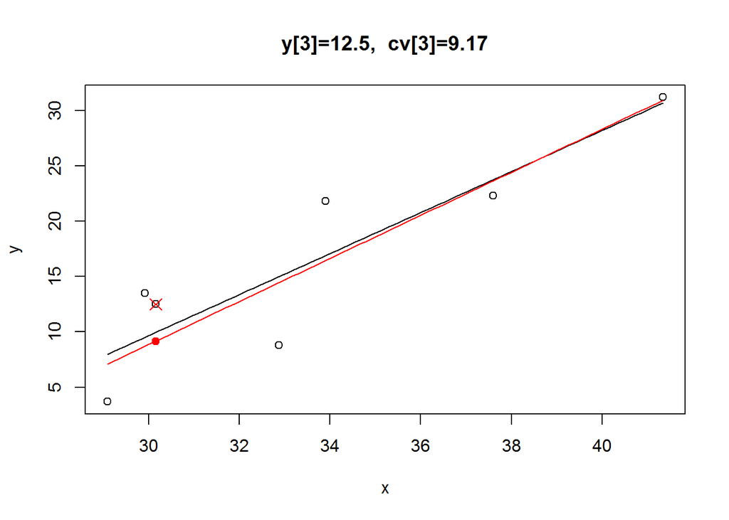

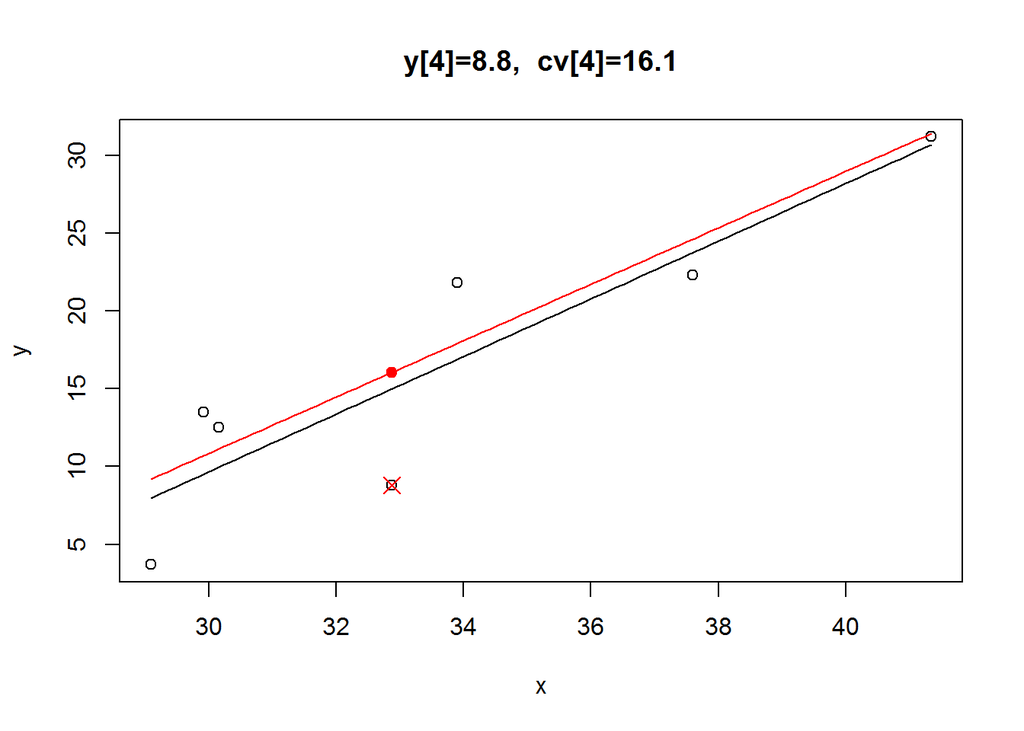

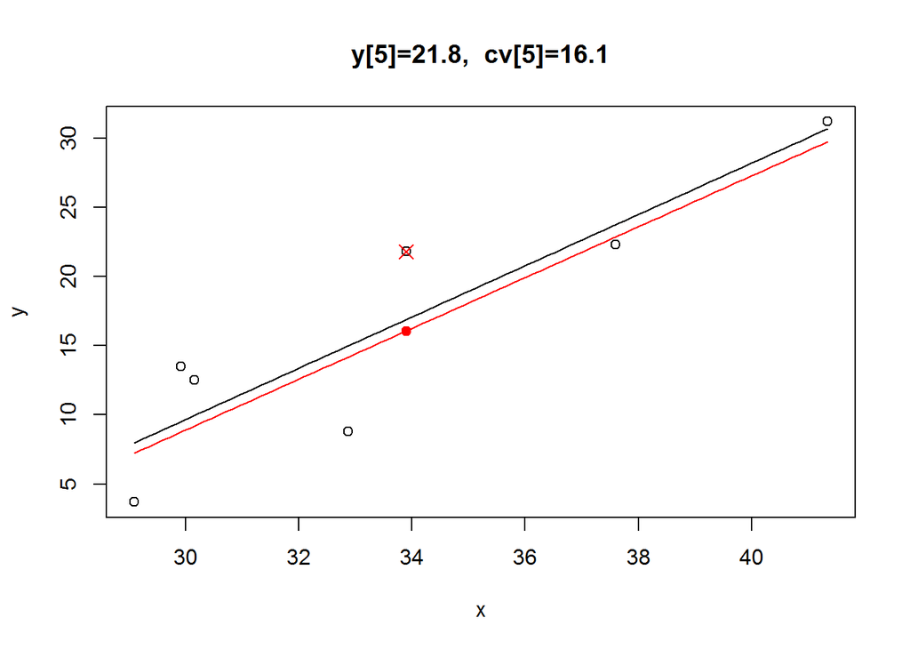

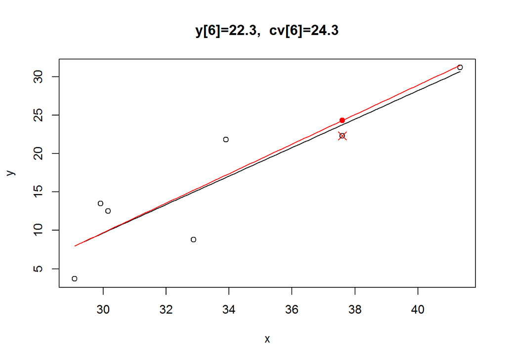

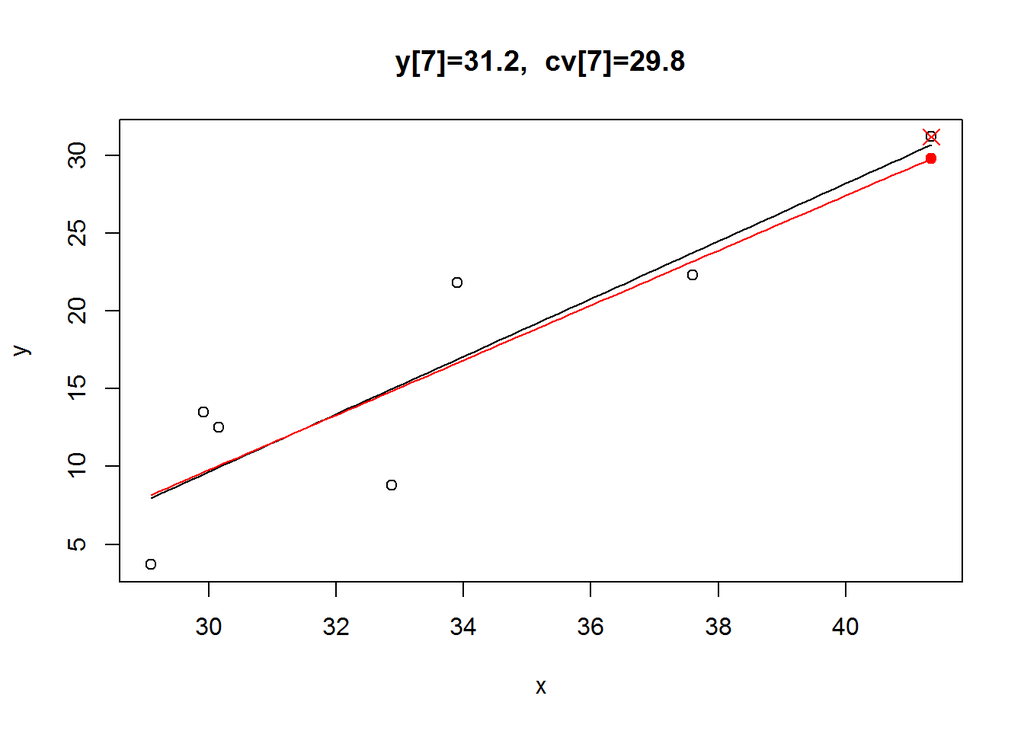

```r
LOO <- function(d, i, ylim=NULL){
  lm0 <- lm(y ~ poly(x,d))
  yi <- y[-i]
  xi <- x[-i]
  lmi <- lm(yi ~ poly(xi,d))
  ypredi <- predict(lmi, newdata = data.frame(xi=x[i]))
  ypredi
  mytitle <- paste0("y[",i,"]=",y[i],",  cv[",i,"]=",signif(ypredi,3))
  plot(y ~ x, main=mytitle, ylim=ylim)
  points(x[i],y[i], pch=4, cex=1.5, col=2)
  L <- min(x); U <- max(x)
  newx <- seq(L,U,length.out = 100)
  pr0 <- predict(lm0, data.frame(x=newx))
  lines(newx, pr0)
  pri <- predict(lmi, data.frame(xi=newx))
  lines(newx, pri, col=2)
  points(x[i], ypredi, pch=19, col=2)
}

for(i in 1:7)LOO(1,i)
```

The last command produced 7 plots; you can use the arrows on the upper left of the plot window to page through the plots.